# 2. Los sistemas de información en los negocios

# 2.1. El impacto de las TI en la sociedad

Negocios

Tecnología

Sociedad

- Online retailing ↑ 20%
- Mobile retailing ↑80.000M€ EU5*
- Apps móviles 2000M usuarios
- Comercio en RRSS ↑ 25.000M€ 2016
- Plataformas de “servicio a demanda”
- Publicidad móvil: 70% publicidad digital
- Pequeños negocios: plataformas de comercio
- Capacidades móviles
- Computación en la nube
- Internet of Things
- Big Data
- Business Analytics
- Contenidos generados por los usuarios
- Amenazas a la privacidad
- Adultos en redes sociales
- Conflictos de copyright
- Aspectos tributarios
- Seguridad de la red
- Empleo precario

*Fuente: Laudon y Guercier (2018)* .footnote[* Francia, Alemania, Italia, España, Reino Unido]

# Los sistemas de información y los objetivos de la empresa

1. Excelencia Operacional
2. Nuevos productos,servicios y modelos de negocio
3. Cercanía / compromiso con clientes y proveedores
4. Mejora en la toma de decisiones
5. Ventaja competitiva
6. Supervivencia

# (a) Excelencia Operacional

### Mejora de la eficiencia de sus operaciones para alcanzar una mayor rentabilidad

.pull-left[**Impacto del SI**: Herramienta de mejora de eficiencia y productividad

Ejemplo: (Logística en Inditex)[https://www.inditex.com/es/un-modelo-sostenible/como-trabajamos/logistica]

Ejemplo: [Walmart Retail Link](http://www.gcretailconsultores.com.mx/blog/que-es-retail-link/)]

.pull-right[

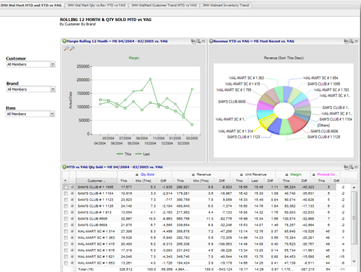

]

# (b) Nuevos productos,servicios y modelos de negocio

### Modelos de negocio: la forma en que una empresa produce, entrega y vende un producto o servicio para crear riqueza

.pull-left[**Impacto del SI**: Generan productos y servicios así como modelos de negocio totalmente nuevos

e.g. [Clothes renting](https://www.renttherunway.com/) ]

.pull-right[

e.g. [Aranzadi Infolex](https://www.infolexnube.es/Account/Login?ReturnUrl=%2f)

[video not shown]

]

# (d) Mejora en la toma de decisiones

### Ante posibles situaciones de falta de información: Sobreproducción o subproducción, mala asignación de los recursos, tiempos de respuesta deficientes, mayores costes y pérdida de clientes

.pull-left[El Corte Inglés y SAP:

[Video](https://www.youtube.com/embed/UnpZt6fcD5o)

- ¿Qué es una solución estandarizada?
- ¿Cuál es el foco de la actividad de El Corte Inglés?
- ¿Cuáles son los retos futuros en retaling? ]

.pull-right[ ## Otros ejemplos de soporte a la toma de decisiones

- [eye tracking](https://imotions.com/eye-tracking/), [EGG](https://neurolabcenter.com/egg) y otras técnicas de neuromarketing
- [Inteligencia Artificial](https://www.puromarketing.com/12/31463/como-inteligencia-artificial-podria-cambiar-completo-sector-retail.html) y [Big Data](https://www.bbvaopenmind.com/articulos/los-big-data-y-el-futuro-de-los-negocios/) ]

# (f) Supervivencia

### Adaptación tecnológica para poder sobrevivir

Un buen SI no es una opción, es una necesidad: adaptación a nuevas realidades.

[figure not shown]